# Accessing MTeQTL Results

Aaron J. Molstad, Wei Sun, Li Hsu

October, 2019

In this document, we provide a simple example of how to access the estimated multi-tissue eQTL weights from the article “A covariance-enhanced approach to multi-tissue joint eQTL mapping with application to transcriptome wide association studies”. First, one must download and unzip “MTeQTLResults.zip”. Then, the user must first specify the file path to where the folder “MTeQTLResults” is stored, e.g.,

```r
filepath <- "~/Desktop"
```

From here, we can source the function used to access results and check

```r
source(paste(filepath, "/MTeQTLResults/getMTeQTLResults.R", sep=""))
str(getMTeQTLResults)
```

```
## function (filepath, gene = NULL, chr = NULL, pos = NULL, extract = NULL)
```

The function we will be using is $\texttt{getMTeQTLResults}$. This function takes five arguments:

1. $\texttt{filepath}:$ the filepath as specified above
2. $\texttt{gene}:$ a list of gene names for which information should be extracted (e.g., “ENSG00000143196”)
3. $\texttt{chr}:$ a list of chromosomes corresponding the positions in the $\texttt{pos}$ argument (e.g., 1)
4. $\texttt{pos}:$ a list of positions which must be the same length as $\texttt{chr}$. If both $\texttt{chr}$ and $\texttt{pos}$ are specified, results will be returned for all available genes where $\texttt{pos}$ is within 1Mb of the TSS or TSE.
5. $\texttt{extract}$: a list with the items to be extracted – options are:
   - $\texttt{beta}$: the eQTL weights for each gene (stored as a $r \times 29$ sparse matrix) with column names denoting the tissues for which each column represents the eQTL weights;
   - $\texttt{Omega}$: the estimated error precision matrix for each gene (stored as a $29 \times 29$ sparse matrix);
   - $\texttt{TSS}$: the transcription start site of the gene;
   - $\texttt{TES}$: the transcription end site of the gene;
   - $\texttt{R2}$: a vector of length 29 with the testing set $R^2$ from the GTEx analysis described in the article;
   - $\texttt{chr}$: the chromosome on which the gene is located.

For example, suppose we wanted the eQTL weights and test set $R^2$ for the gene ENSG00000143196

```r
temp <- getMTeQTLResults(filepath, gene = list("ENSG00000143196"), chr = NULL, pos = NULL, extract = list("beta", "R2"))
str(temp)
```

```
## List of 1
##  $ :List of 3
##   ..$ gene: chr "ENSG00000143196"
##   ..$ beta:
```

```
## Formal class 'dgCMatrix' [package "Matrix"] with 6 slots
##   .. .. ..@ i       : int [1:231] 0 1 2 3 4 5 6 7 0 1 ...
##   .. .. ..@ p       : int [1:30] 0 8 16 24 32 40 48 56 64 72 ...
##   .. .. ..@ Dim     : int [1:2] 8 29
##   .. .. ..@ Dimnames:List of 2
##   .. .. .. ..$ : chr [1:8] "1:168684832:AAAG:A" "1:168737147:A:G" "1:168652905:G:C" "1:168666520:T:A" ...
##   .. .. .. ..$ : chr [1:29] "Adipose - Subcutaneous" "Adipose - Visceral (Omentum)" "Adrenal Gland" "Artery - Aorta" ...
##   .. .. ..@ x       : num [1:231] 0.001403 -0.001106 -0.000673 0.002077 0.010923 ...
##   .. .. ..@ factors : list()
##   ..$ R2  : num [1:29] 0.02058 0.02564 0.06564 0.11727 0.00784 ...
```

It can be seen that the results are stroed as a list with the same length as the list $\texttt{gene}$. Within each element of that list are all the items included in the list $\texttt{extract}$. For example, the eQTL weights for this particular gene are $8 \times 29$:

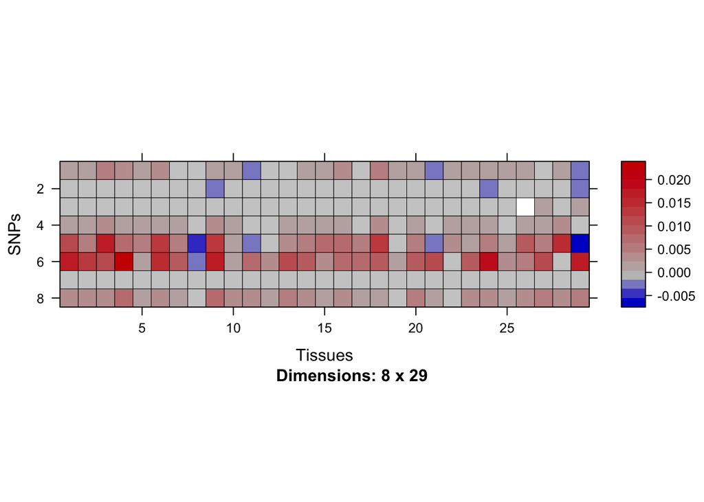

```r
library(Matrix)
image(temp[[1]]$beta, xlab="Tissues", ylab="SNPs")
```

We can also check the testing set $R^2$:

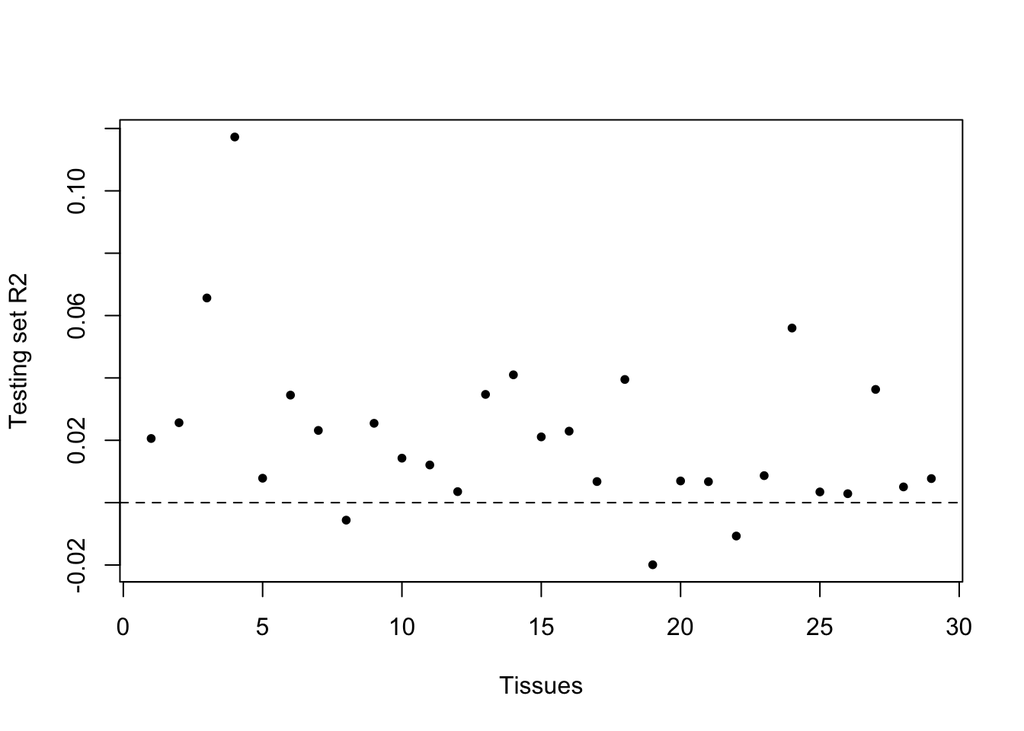

```r
library(Matrix)
plot(temp[[1]]$R2, pch=20, ylab="Testing set R2", xlab="Tissues")
abline(h=0, lty=2)
```

To see which tissue type has relatively high $R^2$, we use the following:

```r
colnames(temp[[1]]$beta)[which.max(temp[[1]]$R2)]
```

```
## [1] "Artery - Aorta"
```

Similarly, one can input a longer list of genes and get out the estimated precision matrices for both genes.

```r
temp2 <- getMTeQTLResults(filepath, gene = list("ENSG00000143196", "ENSG00000144401"), chr = NULL, pos = NULL, extract = list("Omega", "R2"))
str(temp2)
```

```
## List of 2
##  $ :List of 3
##   ..$ gene : chr "ENSG00000143196"
##   ..$ Omega:Formal class 'dgCMatrix' [package "Matrix"] with 6 slots
##   .. .. ..@ i       : int [1:38] 0 19 1 2 3 4 5 20 6 7 ...
##   .. .. ..@ p       : int [1:30] 0 2 3 4 5 6 8 9 10 11 ...
##   .. .. ..@ Dim     : int [1:2] 29 29
##   .. .. ..@ Dimnames:List of 2
##   .. .. .. ..$ : NULL
##   .. .. .. ..$ : chr [1:29] "Adipose - Subcutaneous" "Adipose - Visceral (Omentum)" "Adrenal Gland" "Artery - Aorta" ...
##   .. .. ..@ x       : num [1:38] 0.9108 -0.0096 0.8695 0.7851 0.9197 ...
##   .. .. ..@ factors : list()
##   ..$ R2   : num [1:29] 0.02058 0.02564 0.06564 0.11727 0.00784 ...
##  $ :List of 3
##   ..$ gene : chr "ENSG00000144401"
##   ..$ Omega:Formal class 'dgCMatrix' [package "Matrix"] with 6 slots
##   .. .. ..@ i       : int [1:40] 0 6 23 1 2 3 4 5 14 19 ...
##   .. .. ..@ p       : int [1:30] 0 3 4 5 6 7 10 13 14 15 ...
##   .. .. ..@ Dim     : int [1:2] 29 29
##   .. .. ..@ Dimnames:List of 2
##   .. .. .. ..$ : NULL
##   .. .. .. ..$ : chr [1:29] "Adipose - Subcutaneous" "Adipose - Visceral (Omentum)" "Adrenal Gland" "Artery - Aorta" ...
##   .. .. ..@ x       : num [1:40] 0.9947 -0.0554 -0.0268 0.9385 0.8868 ...
##   .. .. ..@ factors : list()
##   ..$ R2   : num [1:29] 0.0749 0.0516 0.1005 0.0647 0.0104 ...
```

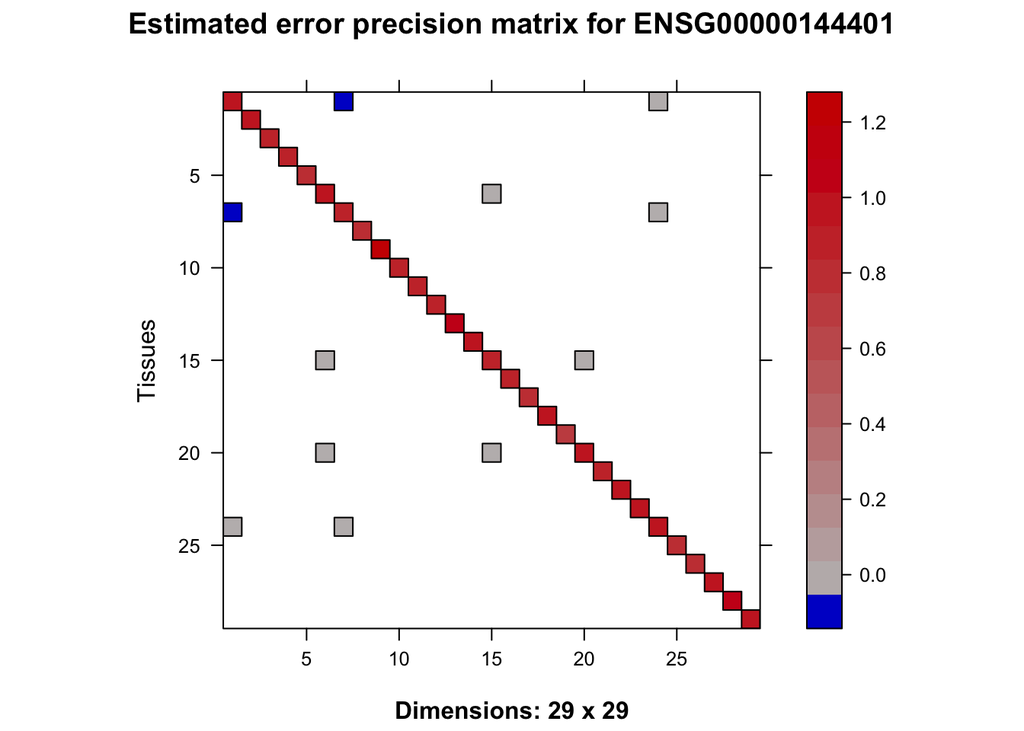

```r
image(temp2[[2]]$Omega, ylab="Tissues", xlab="", main="Estimated error precision matrix for ENSG00000144401")
```

If we would rather input positions and chromosomes than genes, we can use the folowing

```r
temp3 <- getMTeQTLResults(filepath, gene = NULL, chr = list("8", "1"), pos = list("48890700", "10243857"), extract = list("chr", "TSS", "TES", "beta", "R2"))
str(temp3)
```

[output not shown]